# Bernoulli distribution

Ali T. Abdallah

## Bernoulli Distribution

### Story

Imagine you’re trying to determine whether a particular bacterium can survive a certain antibiotic. You place one bacterium in a petri dish with the antibiotic and wait: will it survive (**success**, coded as 1), or will it not survive (**failure**, coded as 0)? Each experiment like this is called a**Bernoulli trial**— an event with just two possible outcomes.

Whenever you have an experiment or process that results in exactly two outcomes, one of which you care about (success, coded as 1) and the other not (failure, coded as 0), the **Bernoulli distribution** is your mathematical model for the outcome.

### Parameter

- **θ (theta):** The probability that the trial results in success (y = 1).
  - θ is a number between 0 and 1.

### Support

- The Bernoulli random variable, **y**, can only take the values 0 or 1.

### Probability Mass Function

$$P(y; \theta) =
\begin{cases}
1 - \theta, & y = 0 \\
\theta, & y = 1 \\
\end{cases}$$

### Example (in R)

Suppose the probability that a bacterium survives the antibiotic is **θ = 0.2**.

You want to simulate the result of this experiment—will a single bacterium survive?

```r
theta <- 0.2
# Simulate the outcome (0 = not survive, 1 = survive)
result <- rbinom(n = 1, size = 1, prob = theta)
cat("Did the bacterium survive? (1 = Yes, 0 = No):", result, "\n")
```

```
Did the bacterium survive? (1 = Yes, 0 = No): 0
```

#### Multiple Trials

If you repeat the experiment with 10 bacteria:

```r
theta <- 0.2
results <- rbinom(n = 10, size = 1, prob = theta)
cat("Survival outcomes of 10 bacteria:", results, "\n")
```

```
Survival outcomes of 10 bacteria: 0 0 0 0 0 0 0 1 0 1
```

### Usage in R

| Package | Syntax |
| --- | --- |
| **Base R** | `rbinom(n, 1, theta)` |
| **stats** | `dbinom(y, 1, theta)` for PMF |

### Related Distributions

- The Bernoulli distribution is a special case of the **Binomial** distribution with `size = 1`.
- If you sum up several independent Bernoulli trials, you get a Binomial- distributed variable.

### Quick Visualization

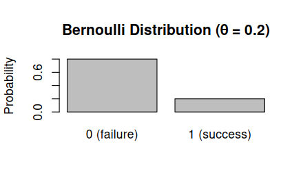

```r
theta <- 0.2
barplot(
  height = c(1-theta, theta),
  names.arg = c("0 (failure)", "1 (success)"),
  ylab = "Probability",
  main = "Bernoulli Distribution (θ = 0.2)"
)
```

**Summary**: The Bernoulli distribution describes the outcome of a single yes/no experiment, parametrized by the probability of success. In R, simulate a Bernoulli trial using `rbinom(1, 1, theta)`.

## Geometric Distribution

### Story

Suppose you’re trying to find the first bacterium in a sequence that is competent (for example, able to take up DNA), and each bacterium has a probability **θ** of being competent. You check each bacterium one by one, and you stop as soon as you find the first competent one. The number of bacteria you test until the first success (competent bacterium) follows a **Geometric distribution**.

The Geometric distribution models the number of *failures* before the first success in a sequence of independent Bernoulli trials, each with the same probability of success.

### Parameter

- **θ (theta):** The probability that any single trial results in success (success = 1).
  - θ is a number between 0 and 1.

### Support

- The Geometric random variable, **y**, can take any non-negative integer value: 0, 1, 2, …
  - (Here, **y** is the number of failures before the first success.)

### Probability Mass Function

$$P(y; \theta) = (1 - \theta)^y \theta,\quad y = 0, 1, 2, ...$$

### Example (in R)

Suppose the probability that a bacterium is competent is **θ = 0.2**.

You want to simulate how many bacteria you need to test before you find the first competent one.

```r
theta <- 0.2
# Simulate the number of failures before the first success
failures_before_success <- rgeom(n = 1, prob = theta)
cat("Number of failures before first competent bacterium:", failures_before_success, "\n")
```

```
Number of failures before first competent bacterium: 0
```

#### Multiple Trials

If you repeat the experiment 10 times:

```r
theta <- 0.2
failures_list <- rgeom(n = 10, prob = theta)
cat("Failures before first competent bacterium in 10 experiments:", failures_list, "\n")
```

```
Failures before first competent bacterium in 10 experiments: 9 0 15 1 14 8 12 1 18 6
```

### Usage in R

| Package | Syntax |
| --- | --- |
| **Base R** | `rgeom(n, theta)` |
| **stats** | `dgeom(y, theta)` for PMF |

### Related Distributions

- The Geometric distribution describes the number of failures before the first success (“zero-based”).
- The waiting time (counting the trial that is the first success) is sometimes called the “shifted” Geometric distribution.
- The Geometric is closely related to the Bernoulli and Negative Binomial distributions.

### Quick Visualization

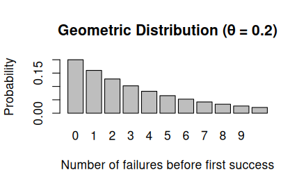

```r
theta <- 0.2
y_vals <- 0:10
pmf_vals <- dgeom(y_vals, prob = theta)
barplot(
  pmf_vals,
  names.arg = y_vals,
  xlab = "Number of failures before first success",
  ylab = "Probability",
  main = "Geometric Distribution (θ = 0.2)"
)
```

**Summary**: The Geometric distribution models how many failures occur before the first success in a sequence of independent Bernoulli trials. In R, simulate with `rgeom(1, theta)`.